# Bayesian Linear Regression via QR Decomposition

Theory, Composition Sampling Algorithms, and Raw R Implementation

Sudipto Banerjee

2026-08-11

*Note:* To generate this HTML file, run `renderRaw.sh` in the terminal from the `src/bayesianLinearRegressionExact/raw/run` directory. Alternatively, find the source `Rmd` and `R` files in that same folder starting from the `BGC_2023` GitHub home.

```bash
# Navigate to the directory and run the compilation script
cd src/bayesianLinearRegressionExact/raw/run
./renderRaw.sh
```

# 1 Introduction and Mathematical Reparameterization

In standard linear regression modeling, parameter estimation and sampling can suffer from severe numerical instability when predictors operate on drastically different scales or display strong multicollinearity. This instability arises primarily when evaluating matrix products such as $X^\top X$ or inverting ill-conditioned covariance matrices.

To achieve optimal numerical stability without altering the physical units or requiring ad-hoc predictor standardization, we apply a **thin QR decomposition** to the design matrix $X \in \mathbb{R}^{n \times p}$:

$$X = QR$$

where:

- $Q \in \mathbb{R}^{n \times p}$ is an orthogonal matrix satisfying $Q^\top Q = I_p$.
- $R \in \mathbb{R}^{p \times p}$ is an upper-triangular matrix with positive diagonal entries.

## 1.1 Model Reparameterization

Substituting $X = QR$ into the linear regression model $y = X\beta + \varepsilon$ yields:

$$y = Q(R\beta) + \varepsilon = Q\theta +
\varepsilon, \quad \varepsilon \sim \mathcal{N}_n(0_{n \times 1}, \,
\sigma^2 I_n)$$

where the transformed parameter vector $\theta \in \mathbb{R}^{p \times 1}$ is defined as:

$$\theta = R\beta \iff \beta =
R^{-1}\theta$$

Because $Q^\top Q = I_p$, the condition number of the design matrix $Q$ in $\theta$-space is identically $1$. This orthogonality completely decouples the numerical updates during posterior inference.

# 2 Efficient Computation of Prior Precision ($M_\theta^{-1}$)

Under a conjugate Gaussian prior on the original parameters $\beta \mid \sigma^2 \sim \mathcal{N}_p\left(m_0, \, \sigma^2 M_0^{-1}\right)$, the induced prior on $\theta = R\beta$ is:

$$\theta \mid \sigma^2 \sim
\mathcal{N}_p\left(m_\theta, \, \sigma^2
M_\theta^{-1}\right)$$

where:

$$m_\theta = R m_0, \quad M_\theta = R M_0
R^\top$$

The joint posterior update requires the prior precision factor $M_\theta^{-1} = (R^\top)^{-1} M_0^{-1} R^{-1}$. Explicitly inverting triangular matrices introduces unnecessary numerical loss. Instead, we evaluate $M_\theta^{-1}$ using **two sequential lower-triangular matrix solves** with $R^\top$:

1. **First Solve:** Solve the lower-triangular system $R^\top A = M_0^{-1}$ for $A \in \mathbb{R}^{p \times p}$ via forward-substitution:
   $$A = (R^\top)^{-1}
   M_0^{-1} \quad \text{(R code: `A <- forwardsolve(t(R),
   M0_inv)`)}$$
2. **Second Solve:** Note that $M_\theta^{-1} = A R^{-1} \implies M_\theta^{-1} R = A$. Taking the transpose yields:
   $$R^\top M_\theta^{-1} = A^\top \quad \text{(R
   code: `M_theta_inv <- forwardsolve(t(R), t(A))`)}$$

This approach completely eliminates explicit matrix inversions, preserves numerical precision, and operates in $O(p^3)$ triangular solves.

# 3 Composition Sampling Algorithms for Parameter Inference

We will draw *exact* posterior samples from the joint posterior distribution $p( \beta,\sigma^2 \mid y)$ using **Composition Sampling.** Here is a brief overview of compostion sampling. Composition sampling provides a method to draw exact samples from a joint distribution by utilizing marginal and conditional sampling. For two random variables $X$ and $Y$ with a joint density function $f(X,Y)$, the density at $(x,y)$ can be written as $f_{X,Y}(x,y) = f_X(x)f_{Y|X}(y|x)$. Suppose we can draw samples from $f_X$ and $f_{Y|X}$ for any given $X = x$. To generate $N$ samples from this joint distribution, one first draws a sample $X_i^* = x_i \sim f_X$ from the marginal distribution of $X$ for $i = 1, \dots, N$. Then, for each drawn value $x_i$, a subsequent sample $Y_i^* \sim f_{Y|X}(\cdot \mid x_i)$ is drawn for $i = 1,\dots, N$.

In conjugate models, it is often easy to draw samples from $p(\theta_1 \mid y)$ and from $p(\theta_2 \mid \theta_1, y)$. We first draw $N$ samples $\theta_{1(i) } \sim p(\theta_1 \mid y)$ and, for each drawn value $\theta_{1(i)}$, we draw $\theta_{2(i)} \sim p(\theta_2 \mid \theta_{1(i)}, y)$. Hence, in Bayesian linear regression, we first draw $\sigma^2i_{(i)} \sim p(\sigma^2 \mid y)$ and then draw $\beta_{(i)} \sim p(\beta \mid y, \sigma^2_{(i)})$ using the previously drawn value of $\sigma^2_{(i)}$.

## 3.2 Algorithm 2: Non-Informative (Jeffreys) Flat Prior Case

**Inputs:** Response vector $y \in \mathbb{R}^n$, unscaled design matrix $X \in \mathbb{R}^{n \times p}$, and requested draw count $N$.

1. Perform QR decomposition on $X$ to obtain $Q \in \mathbb{R}^{n \times p}$ and upper-triangular $R \in \mathbb{R}^{p \times p}$.
2. Compute orthogonal OLS estimate and sum of squared errors:
   $$\hat{\theta}_{\text{OLS}} = Q^\top y, \quad
   \text{SSE} = y^\top y - \hat{\theta}_{\text{OLS}}^\top
   \hat{\theta}_{\text{OLS}}$$
3. Set posterior Inverse-Gamma parameters:
   $$a_n = \frac{n - p}{2}, \quad b_n =
   \frac{\text{SSE}}{2}$$
4. Vectorized sampling across all $N$ draws:
   1. Draw $\sigma^{2(1:N)} \sim \text{Inv-Gamma}\left(a_n, \, b_n\right)$.
   2. Draw $\Theta = \hat{\theta}_{\text{OLS}} \mathbf{1}_N^\top + Z \cdot \text{diag}\left(\sigma^{(1:N)}\right)$, where $Z \in \mathbb{R}^{p \times N} \sim \mathcal{N}(0, 1)$.
   3. Recover natural regression parameters $\mathcal{B} = \text{backsolve}(R, \Theta)^\top$.
5. Return posterior samples $\left(\mathcal{B}, \sigma^{2(1:N)}\right)$.

# 4 Posterior Predictive Sampling for New Data ($X_{\text{new}}$)

Once posterior samples $\left(\mathcal{B}, \sigma^{2(1:N)}\right)$ are generated, we can make predictions for new covariate observations $X_{\text{new}} \in \mathbb{R}^{n_{\text{new}} \times p}$.

## 4.1 Conceptual Note: Why We Do Not Decompose $X_{\text{new}}$

It is a common question whether one should perform a separate QR decomposition $X_{\text{new}} = Q_{\text{new}} R_{\text{new}}$. The answer is **no**:

1. **Numerical Stability:** QR decomposition is applied to $X$ during model training to prevent numerical breakdown in matrix inversions (e.g., inverting $X^\top X$). Prediction is a forward matrix-vector multiplication: $\mu_{\text{new}}^{(s)} = X_{\text{new}}\beta^{(s)}$. This operation requires zero matrix solves or inversions and is inherently stable regardless of predictor scaling in $X_{\text{new}}$.
2. **Mathematical Incompatibility:** The reparameterized vector $\theta$ is tied to the training matrix factor via $R_{\text{train}}\beta = \theta$. A separate decomposition $X_{\text{new}} = Q_{\text{new}} R_{\text{new}}$ yields a completely different factor $R_{\text{new}} \neq R_{\text{train}}$. Consequently, $Q_{\text{new}}\theta^{(s)} \neq X_{\text{new}}\beta^{(s)}$, producing mathematically invalid predictions.

# 5 Clarification: Centered Intercept ($\alpha$) vs. Raw Intercept ($\beta_0$)

# 6 Raw R Code for Bayesian Inference with QR Decomposition

In this section, we evaluate the QR-based sampling workflow using executable R code. We compare the computational accuracy of `rawSamplerWithQR()` against `rawSampler.r`.

## 6.1 Setup and Source Files

We source the required sampler routines directly from the `../src/` directory:

```r
# Source raw sampler implementations from ../src/
source("../src/rawSampler.r")
source("../src/rawSamplerWithQR.r")
source("../src/rawPosteriorPredictive.r")

library(knitr)
```

To test numerical stability, we simulate a dataset where the predictor variables operate on vastly different scales ($X_1 \in [0, 1]$ versus $X_2 \in [10^4, 10^5]$).

```r
set.seed(2026)
n <- 250
p <- 3
N_samples <- 10000

# Predictors with extreme scale differences
X_raw <- cbind(
  Intercept = 1,
  X1 = runif(n, 0, 1),
  X2 = runif(n, 1e4, 1e5)
)

true_beta <- c(12.5, -4.2, 0.00085)
true_sigma2 <- 4.0

# Generate response y
y <- as.numeric(X_raw %*% true_beta + rnorm(n, mean = 0, sd = sqrt(true_sigma2)))
```

## 6.2 Posterior Inference and Comparisons

We fit both models under a non-informative flat Jeffreys prior ($M_0^{-1} = 0_{p \times p}$, $m_0 = 0_{p \times 1}$, $a_0 = -p/2$, $b_0 = 0$):

1. **Standardized Predictor Sampler (`rawSampler.r`):** Centers and scales $X$ prior to sampling, then converts back to original units.
2. **QR Reparameterized Sampler (`rawSamplerWithQR.r`):** Operates on centered predictors using QR decomposition ($X_c = QR$).

```r
# Set flat prior parameters
m0 <- rep(0, p)
M0_inv <- matrix(0, p, p)
a0 <- -p / 2
b0 <- 0

# -----------------------------------------------------------------------------
# Method 1: Standardized Sampler (rawSampler.r)
# -----------------------------------------------------------------------------
X_center <- colMeans(X_raw[, -1])
X_scale  <- apply(X_raw[, -1], 2, sd)
X_scaled <- cbind(Intercept = 1, scale(X_raw[, -1]))

res_scaled <- rawSampler(y, X_scaled, m0, M0_inv, a0, b0, N_samples)

# Centered intercept draws (alpha ~ y_bar)
alpha_scaled_draws <- res_scaled$beta[, 1]

# Unscale Beta draws back to raw data units (Vectorized)
beta_scaled_draws <- res_scaled$beta
beta_unscaled_draws <- beta_scaled_draws
beta_unscaled_draws[, 2:3] <- sweep(beta_scaled_draws[, 2:3], 2, X_scale, "/")
beta_unscaled_draws[, 1]   <- beta_scaled_draws[, 1] -
  rowSums(sweep(beta_scaled_draws[, 2:3], 2, X_center / X_scale, "*"))

# -----------------------------------------------------------------------------
# Method 2: QR Sampler on Centered Predictors (rawSamplerWithQR.r)
# -----------------------------------------------------------------------------
X_centered <- cbind(Intercept = 1, scale(X_raw[, -1], center = TRUE, scale = FALSE))
qr_X <- qr(X_centered)
Q <- qr.Q(qr_X)
R <- qr.R(qr_X)

res_qr <- rawSamplerWithQR(y, Q, R, m0, M0_inv, a0, b0, N_samples)

# Centered intercept draws (alpha ~ y_bar)
alpha_qr_draws <- res_qr$beta[, 1]

# Convert centered QR Beta draws to raw unscaled predictors (Vectorized)
beta_qr_draws <- res_qr$beta
beta_unscaled_qr <- beta_qr_draws
beta_unscaled_qr[, 1] <- beta_qr_draws[, 1] - rowSums(sweep(beta_qr_draws[, 2:3], 2, X_center, "*"))
```

### 6.2.1 Tabular Posterior Summary Comparison

Below is a comparison of posterior means, standard deviations, and 95% credible intervals across both methods, displaying both the centered intercept ($\alpha$) and the uncentered raw intercept ($\beta_0$):

Posterior Estimation Comparison: rawSampler vs. rawSamplerWithQR

| Parameter | Method | Mean | SD | 2.5% | 97.5% |
| --- | --- | --- | --- | --- | --- |
| alpha (Centered Intercept ~ y_bar) | rawSampler (Standardized X) | 58.995732 | 0.135775 | 58.731772 | 59.257208 |
| alpha (Centered Intercept ~ y_bar) | rawSamplerWithQR (Centered X) | 58.994918 | 0.136838 | 58.722738 | 59.258617 |
| beta_0 (Raw Intercept at X=0) | rawSampler (Standardized X) | 12.224084 | 0.384158 | 11.465793 | 12.968909 |
| beta_0 (Raw Intercept at X=0) | rawSamplerWithQR (Centered X) | 12.231534 | 0.383671 | 11.485261 | 12.982571 |
| beta_1 (X1) | rawSampler (Standardized X) | -3.825205 | 0.461321 | -4.724270 | -2.919962 |
| beta_1 (X1) | rawSamplerWithQR (Centered X) | -3.833740 | 0.461263 | -4.742834 | -2.914331 |
| beta_2 (X2) | rawSampler (Standardized X) | 0.000853 | 0.000006 | 0.000842 | 0.000864 |
| beta_2 (X2) | rawSamplerWithQR (Centered X) | 0.000853 | 0.000006 | 0.000842 | 0.000864 |
| sigma^2 | rawSampler (Standardized X) | 4.594793 | 0.417557 | 3.861268 | 5.492031 |
| sigma^2 | rawSamplerWithQR (Centered X) | 4.605899 | 0.414196 | 3.865073 | 5.493492 |

### 6.2.2 Quantile-Quantile (Q-Q) Plots for Posterior Parameter Draws

To visually verify that both samplers produce identical empirical posterior distributions, we construct Q-Q plots for each parameter draw:

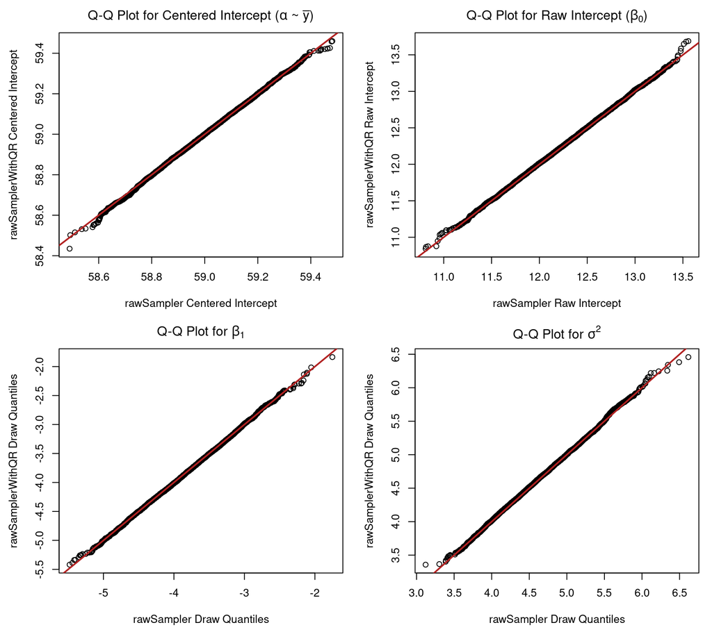

```r
par(mfrow = c(2, 2), mar = c(4.5, 4.5, 2.5, 1))

qqplot(alpha_scaled_draws, alpha_qr_draws,
       xlab = "rawSampler Centered Intercept", ylab = "rawSamplerWithQR Centered Intercept",
       main = expression("Q-Q Plot for Centered Intercept (" * alpha * " ~ " * bar(y) * ")"))
abline(0, 1, col = "firebrick", lwd = 2)

qqplot(beta_unscaled_draws[, 1], beta_unscaled_qr[, 1],
       xlab = "rawSampler Raw Intercept", ylab = "rawSamplerWithQR Raw Intercept",
       main = expression("Q-Q Plot for Raw Intercept (" * beta[0] * ")"))
abline(0, 1, col = "firebrick", lwd = 2)

qqplot(beta_unscaled_draws[, 2], beta_unscaled_qr[, 2],
       xlab = "rawSampler Draw Quantiles", ylab = "rawSamplerWithQR Draw Quantiles",
       main = expression("Q-Q Plot for " * beta[1]))
abline(0, 1, col = "firebrick", lwd = 2)

qqplot(res_scaled$sigma2, res_qr$sigma2,
       xlab = "rawSampler Draw Quantiles", ylab = "rawSamplerWithQR Draw Quantiles",
       main = expression("Q-Q Plot for " * sigma^2))
abline(0, 1, col = "firebrick", lwd = 2)
```

The sample quantiles lie directly along the $45^\circ$ reference line ($y = x$), demonstrating exact empirical distribution equivalence between `rawSampler()` and `rawSamplerWithQR()`.

## 6.3 Posterior Predictive Inference and Comparisons

We evaluate posterior predictive sampling for a new matrix of unscaled test observations $X_{\text{new}} \in \mathbb{R}^{m_{\text{test}} \times p}$ using `rawPosteriorPredictive()`:

```r
m_test <- 100
X_new_raw <- cbind(
  Intercept = 1,
  X1 = runif(m_test, 0, 1),
  X2 = runif(m_test, 1e4, 1e5)
)

# 1. Predictions using rawSamplerWithQR Draws
Y_pred_qr <- rawPosteriorPredictive(X_new_raw, beta_unscaled_qr, res_qr$sigma2)

# 2. Predictions using rawSampler Draws (unscaled parameters)
Y_pred_scaled <- rawPosteriorPredictive(X_new_raw, beta_unscaled_draws, res_scaled$sigma2)
```

### 6.3.1 Posterior Predictive Quantile-Quantile (Q-Q) Plots

We select four individual test observations across $X_{\text{new}}$ and compare their posterior predictive distributions $y_{\text{new}}$:

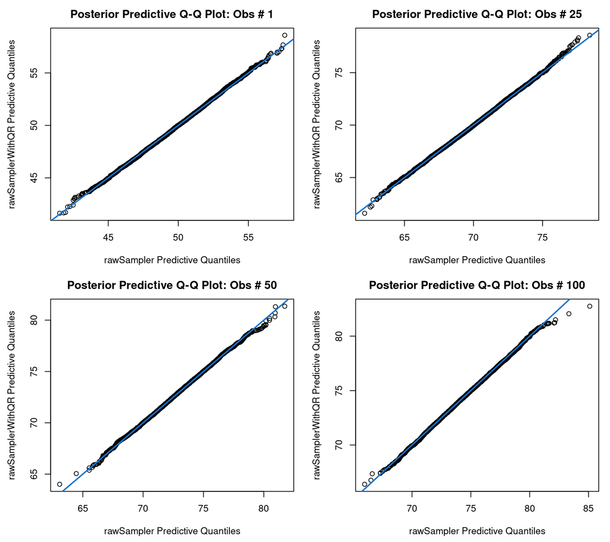

```r
par(mfrow = c(2, 2), mar = c(4.5, 4.5, 2.5, 1))

test_indices <- c(1, 25, 50, 100)
invisible(lapply(test_indices, function(idx) {
  qqplot(Y_pred_scaled[idx, ], Y_pred_qr[idx, ],
         xlab = "rawSampler Predictive Quantiles",
         ylab = "rawSamplerWithQR Predictive Quantiles",
         main = paste("Posterior Predictive Q-Q Plot: Obs #", idx))
  abline(0, 1, col = "dodgerblue3", lwd = 2)
}))
```